# Final Project Research Summary - Intro to Data Science - 6101

Akshat Saini, Daqian Dang, Devon Wan

2022-04-27

**Credit Card Approval Prediction Analysis**

# 1 Introduction

Credit scores are a common risk control method used in the financial industry. It uses personal information and data submitted by credit card customers to predict the probability of any future defaults or credit card borrowings. The bank is then able to decide whether to issue a credit card to the applicant or simply deny. Credit scores can objectively quantify the magnitude of risk.

Generally speaking, credit scores are based on historical data. Past models may lose their original predictive power. Logistic regression is one of the common predictors since it produces a binary target output.

At present, with the development of more machine learning algorithms, other predictive methods such as Random Forest, Support Vector Machines (SVC) etc. have been introduced into credit scoring. However, it is usually difficult with these methods to provide customers and regulators with a reason for rejection or acceptance.

## 1.1 Dataset Source

The study on credit card approval prediction was conducted using a free data set which was sourced from Kaggle. The data set originally consists of 2 separate csv files that are connected to each other via the ‘ID’ column.

# 2 Preparation, Initial Analysis, and Data Tidying:

The first csv file, application record.csv, consists of personal and socio-economic data that is related to an applicant and can usually help a bank decide whether to issue them a credit card or not. The second csv file, credit_record.csv, consists of past credit card usage behavior of an applicant. It consists of information such as defaults, payment due dates etc. We will perform a ‘left join’ to merge these two files and so that we are working with the right applicants and will get rid of the extra rows depending on the Null values.

```r
df <- merge(credit1, credit2, by = 'ID', all.x = TRUE)
```

Checking NA values in the updated dataframe and performing cleanup in the dataframe columns. ‘Occupation_type’ variable has nearly 350000 NaN values in the original dataframe, along with ‘Status’ and ‘months_balance’ columns. We go ahead and clean these rows since there arleady are over a million rows in the data set.

```r
sum(is.na(df$OCCUPATION_TYPE))
# Removing the NA values from the above columns:
new_df <- na.omit(df, c("STATUS", "MONTHS_BALANCE", "OCCUPATION_TYPE"))
# Making sure the dataframe has distinct values:
df2 <- distinct(new_df, ID, .keep_all = TRUE)
```

After removing the NaN values from the three columns, we have generated a new data set with distinct ID values to make sure no two customers or applicants are the same. The generated `data frame(df2)` has 25134 rows and 20 variables.

Removing excess columns or ones that do not pertain to the target variable at all. We have removed FLAG_EMAIL, FLAG_PHONE, FLAG_WORK_PHONE, DAYS_EMPLOYED, DAYS_BIRTH, ID, OCCUPATION_TYPE from the data set and renamed the rest of the columns to more generic values.

```r
df2 <- subset( df2, select = -c(FLAG_EMAIL, FLAG_PHONE, FLAG_WORK_PHONE, DAYS_EMPLOYED, DAYS_BIRTH, ID, OCCUPATION_TYPE))
df2$ID <- 1:nrow(df2)
df2 <- df2 %>% relocate(ID, .before = CODE_GENDER)
# Renaming columns to more generic values:
df2 <- df2 %>% rename(gender = CODE_GENDER, owns_car = FLAG_OWN_CAR, owns_realty = FLAG_OWN_REALTY, children = CNT_CHILDREN, total_income = AMT_INCOME_TOTAL, employment_type = NAME_INCOME_TYPE, education_status = NAME_EDUCATION_TYPE, marital_status = NAME_FAMILY_STATUS, housing_type = NAME_HOUSING_TYPE, owns_mobile = FLAG_MOBIL, family_members = CNT_FAM_MEMBERS, months_due = MONTHS_BALANCE, status = STATUS)

df2$months_due <- df2$months_due * (-1)
```

The structure of the data frame is as follows:

gender : Gender of the applicant, owns_car : Whether the customer owns a car or not, owns_realty : Whether the customer owns realty or not, children : Number of children, total_income : Total income of the customer, employment_type : Employment type, education_status : Education status of the customer, marital_status : Customers marital status, housing_type : Customers housing type, owns_mobile : Whether the customer owns a mobile phone or not, family_members : Number of family members of the customer, months_due : Months behind in payment, status = Target variable or Status

Converting all categorical values to ordinal/numeric values for further computation:

```r
df2$gender <- replace(df2$gender, df2$gender=="M", 1)
df2$gender <- replace(df2$gender, df2$gender=="F", 0)
df2$gender <- as.numeric(df2$gender)

df2$owns_car <- replace(df2$owns_car, df2$owns_car=="Y", 1)
df2$owns_car <- replace(df2$owns_car, df2$owns_car=="N", 0)
df2$owns_car <- as.numeric(df2$owns_car)

df2$owns_realty <- replace(df2$owns_realty, df2$owns_realty=="Y", 1)
df2$owns_realty <- replace(df2$owns_realty, df2$owns_realty=="N", 0)
df2$owns_realty <- as.numeric(df2$owns_realty)

df2$employment_type <- replace(df2$employment_type, df2$employment_type=="Working", 0)
df2$employment_type <- replace(df2$employment_type, df2$employment_type=="Commercial associate", 1)
df2$employment_type <- replace(df2$employment_type, df2$employment_type=="State servant", 2)
df2$employment_type <- replace(df2$employment_type, df2$employment_type=="Student", 3)
df2$employment_type <- replace(df2$employment_type, df2$employment_type=="Pensioner", 4)
df2$employment_type <- as.numeric(df2$employment_type)

df2$education_status <- replace(df2$education_status, df2$education_status=="Secondary / secondary special", 0)
df2$education_status <- replace(df2$education_status, df2$education_status=="Higher education", 1)
df2$education_status <- replace(df2$education_status, df2$education_status=="Incomplete higher", 2)
df2$education_status <- replace(df2$education_status, df2$education_status=="Lower secondary", 3)
df2$education_status <- replace(df2$education_status, df2$education_status=="Academic degree", 4)
df2$education_status <- as.numeric(df2$education_status)

df2$marital_status <- replace(df2$marital_status, df2$marital_status=="Married", 0)
df2$marital_status <- replace(df2$marital_status, df2$marital_status=="Single / not married", 1)
df2$marital_status <- replace(df2$marital_status, df2$marital_status=="Civil marriage", 2)
df2$marital_status <- replace(df2$marital_status, df2$marital_status=="Separated", 3)
df2$marital_status <- replace(df2$marital_status, df2$marital_status=="Widow", 4)
df2$marital_status <- as.numeric(df2$marital_status)

df2$housing_type <- replace(df2$housing_type, df2$housing_type=="House / apartment", 0)
df2$housing_type <- replace(df2$housing_type, df2$housing_type=="Rented apartment", 1)
df2$housing_type <- replace(df2$housing_type, df2$housing_type=="Municipal apartment", 2)
df2$housing_type <- replace(df2$housing_type, df2$housing_type=="With parents", 3)
df2$housing_type <- replace(df2$housing_type, df2$housing_type=="Co-op apartment", 4)
df2$housing_type <- replace(df2$housing_type, df2$housing_type=="Office apartment", 5)
df2$housing_type <- as.numeric(df2$housing_type)

df2$status <- replace(df2$status, df2$status=="0", 0)
df2$status <- replace(df2$status, df2$status=="X", 0)
df2$status <- replace(df2$status, df2$status=="C", 0)
df2$status <- replace(df2$status, df2$status=="1", 0)
df2$status <- replace(df2$status, df2$status=="2", 1)
df2$status <- replace(df2$status, df2$status=="3", 1)
df2$status <- replace(df2$status, df2$status=="4", 1)
df2$status <- replace(df2$status, df2$status=="5", 1)
df2$status <- as.factor(df2$status)
```

## 2.1 Target variable and Data set balancing

The target variable ‘status’ has the following categories: 0: 1-29 days past due 1: 30-59 days past due 2: 60-89 days overdue 3: 90-119 days overdue 4: 120-149 days overdue 5: Overdue or bad debts, write-offs for more than 150 days C: paid off that month X: No loan for the month

Since the test model is based on Binomial Logistic regression, the STATUS column or the target variable has been divided into two separate categories - `risk` and `not a risk`. Customers that are overdue for more than 60 days are marked as `risk` or 1 in the target variable. All other customers are marked as 0.

The target variable - status now has a binary outcome, 1 or 0, predicting if an applicant will be a `risk` or `not a risk`.

```r
table(df2$status)
```

We can see that the dataset is highly unbalanced as there are 25068 customers that have paid off the debt or who are `not a risk` and just 66 customers that are marked as ‘risk’ or who have not yet paid off their debt. The positive class - 1(risk customers) just accounts for 0.263% of the overall dataset. This is extremely imbalanced and a model created with such a set will lead to majority of the values being classified as `not a risk` or 0.

We can balance the dataset using many techniques such as undersampling and oversampling. However, general oversampling of the data set in many cases leads to creation of duplicate values which the team is trying to avoid.

We will balance the dataset using a minority oversampling technique called `SMOTE: Synthetic Minority Oversampling Technique`. This technique uses KNN or K-nearest neighbors algorithm to generate synthetic or artificial values of the under represented category in the target variable. The values that are generated using SMOTE are synthetic and are close to the actual values but not duplicates.

```r
library(DMwR)
df2_bal <- SMOTE(status~., df2, perc.over=6000, perc.under=100, k = 5)
table(df2_bal$status)
```

Now, the data set is completely balanced with the target variable having 3960 customers marked as ‘0’ or ‘not a risk’ and 4026 customers marked as ‘1’ or ‘risk’. We can go ahead and check for data set normality in the balanced data set.

## 2.2 Checking data normality on the df2_bal set

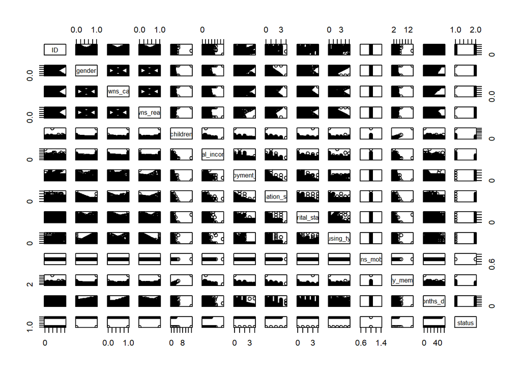

```r
loadPkg("psych")
pairs(df2_bal)
```

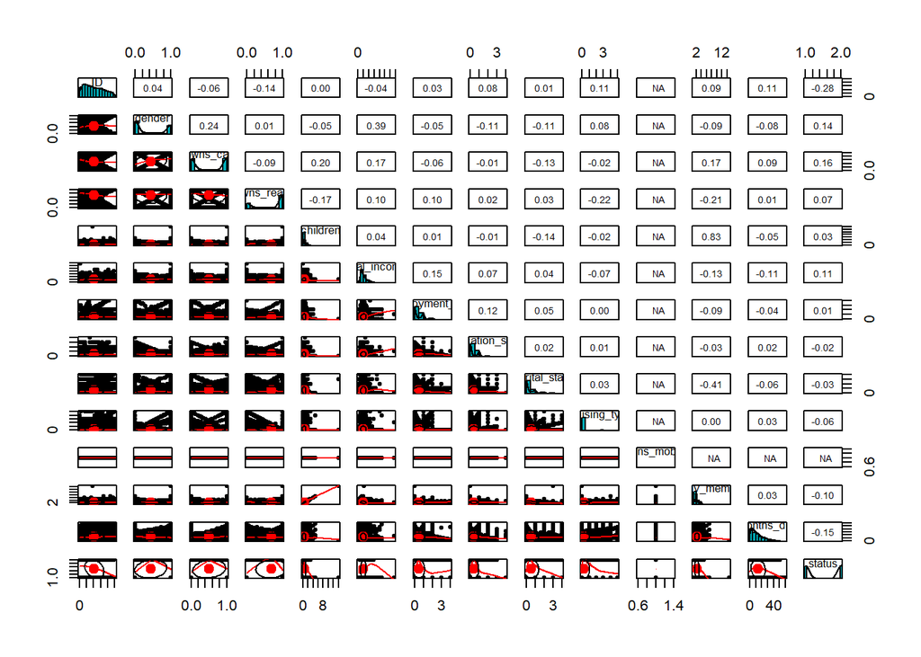

```r
pairs.panels(df2_bal,
             method = "pearson", # correlation method
             hist.col = "#00AFBB", # set histogram color, can use "#22AFBB", "red",
             density = TRUE,  # show density plots
             ellipses = TRUE # show correlation ellipses
             )
```

```r
unloadPkg(psych)
```

# 3 Chi-squared tests

The basic purpose of the chi-squared test used for the data set is that we wanted to investigate whether the test of independence can be used to examine the relationship between the Status as the target variable or the binary variable (y) and other independent variables. We decided to select five independent variables, an applicant’s ownership of realty, an applicant’s total income, an applicant’s marital status, an applicant’s education status, and an applicant’s monthly balance due, to test if the relationship between the binary variable “Status” and other five variables are independent.

## 3.1 To test if the data support that applicant’s owned realty much affects status

```r
own_realty_status_table = xtabs(~owns_realty+status, data = df2_bal)
own_realty_status_table
```

```r
chisqres_own_realty = chisq.test(own_realty_status_table)
chisqres_own_realty
```

The p-value is significantly low suggesting that the target variable is dependent of the owns_realty variable.

## 3.2 To test if the data support that applicant’s total income much affects status

```r
totalincome_statustable = xtabs(~total_income + status, data = df2_bal)
totalincome_statustable
```

```r
chisqres_totalincome = chisq.test(totalincome_statustable)
chisqres_totalincome
```

The p-value shows significantly low suggesting that the target variable is dependent of the total_income variable.

## 3.3 To test if the data support that applicant’s marital status much affects status

```r
maritalstatus_status_table = xtabs(~marital_status+status, data = df2_bal)
maritalstatus_status_table
```

```r
chisqres_maritalstatus = chisq.test(maritalstatus_status_table )
chisqres_maritalstatus
```

The p-value displays significantly low suggesting that the target variable is dependent of the marital variable.

## 3.4 To test if the data support that applicant’s education status much affects status

```r
education_status_table = xtabs(~education_status + status, data = df2_bal)
education_status_table
```

```r
chisqres_education = chisq.test(education_status_table)
chisqres_education
```

The p-value is significantly low suggesting that the target variable is dependent of the education_status variable.

## 3.5 To test if the data support that applicant’s months_due much affects status

```r
months_due_status_table = xtabs(~months_due + status, data = df2_bal)
months_due_status_table
```

```r
chisqres_monthsBalance = chisq.test(months_due_status_table)
chisqres_monthsBalance
```

The p-value shows significantly low suggesting that the target variable is dependent of the months_due variable.

We used chi-square as the test of independence to test five variables, owns_realty, total_income, marital_status, education_status, and months_due, with the binary variable “Status”. As a result, their p-values are extremely smaller than 0.05, which allows us to reject the null Hypothesis. That means the five variables have a significant relation with ‘status’ variable or affect each other in some ways.

# 4 Splitting the balanced set into Train/Test:

Splitting the model into train and test data sets using the ‘caTools’ library. This will allow us to train the model on one data set and then test its accuracy on the latter test set. We will split the data set in 80/20 ratio, where the train set is 80% of the data set and test set is the remaining 20%.

The rows are selected randomly by the ‘caTools’ library.

```r
library(caTools)
split <- sample.split(df2_bal$status, SplitRatio = 0.80)

train <- subset(df2_bal, split == TRUE)
test <- subset(df2_bal, split == FALSE)


## Let's check the count of unique value in the target variable
as.data.frame(table(train$status))
```

# 5 Logit Model 1:

## 5.1 Creating a Logistic regression model with the train dataset:

```r
model <- glm(status~., data = train, family = binomial)
summary(model)
```

Fitting the logistic regression model with the train data set.

## 5.2 Predicting the target values using the generated model against the test data set:

```r
predict_set <- predict(model, test, type = 'response')
```

Now, comparing the original values in the test data set with the predicted values.

A contingency table lets us compare the results visually as in a confusion matrix.

```r
table(test$status, predict_set > 0.5)
```

- y axis - truth values
- x axis - predicted values
- 532 customers were predicted as 0 or not a risk and 532 customers were predicted as not risk by the model.
- 255 customers were 1 or risk but 255 customers were predicted as not risk or 0 by the model.
- 260 customers were 0 or not risk but 260 customers were predicted as risk or 1 by the model.
- 550 customers were 1 or risk and 550 customers were predicted as risk or 1 by the model.

Now, calculating the Accuracy, precision and recall of the generated model:

Accuracy = 0.678 Precision = .679 Recall = 0.683

```r
#                         predicted
#                   0                  1
# Actual 0   True Negative  TN      False Positive FP
# Actual 1   False Negative FN      True Positive  TP
#
#
# Accuracy    = (TP + TN) / Total
# Precision   = TP / (TP + FP)
# Recall rate = TP / (TP + FN) = Sensitivity
# Specificity = TN / (TN + FP)
# F1_score is the "harmonic mean" of precision and recall
#          F1 = 2 (precision)(recall)/(precision + recall)
Accuracy = 0.678
Precision = .679
Recall = 0.683
```

Accuracy of the model is `67.8%`.

We will also generate the ROC and the AUC to evaluate the results.

## 5.3 Generating the ROC:

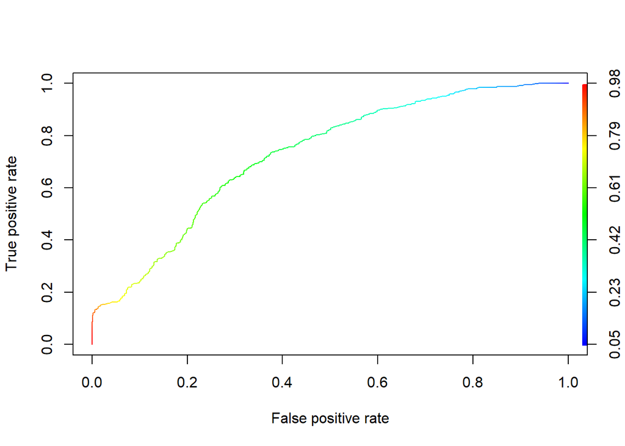

```r
library(pROC)
library(ROCR)
ROCRpred <- prediction(predict_set, test$status)
ROCRperf <- performance(ROCRpred, 'tpr','fpr')
plot(ROCRperf, colorize = TRUE, text.adj = c(-0.2,1.7))
```

```r
ROC_prob = roc(test$status, predict_set, type = "response")
auc(ROC_prob)
```

Area under the curve: `0.713`

A general rule to follow suggesting that AUC or are under the curve should be 0.80 or above. Since 0.713 is close to 0.80, we will perform feature selection on the data set to select the variables with the highest variance on the set and then compare the accuracy of the model again!

# 6 Feature Selection:

The purpose of feature selection is the process of analyzing a subset of a dataset or identifying key elements or series of a data to use in a model. Now, we want to perform feature selection on the dataset to select ideal variables that cause a variation in the target variable.

## 6.1 Performing Exhaustive Search

Model selection by exhaustive (default) search, forward or backward stepwise, or sequential replacement. The plot will essentially show the Adjusted R^2 when using the variables across the bottom

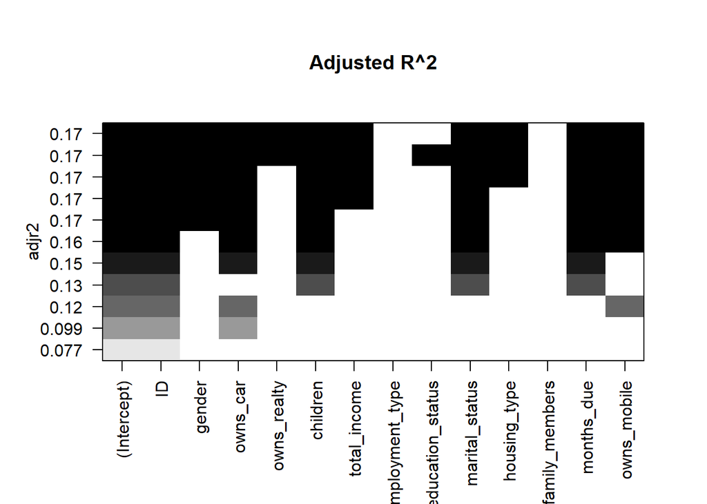

```r
library(ISLR)

loadPkg("leaps")
#This is essentially best fit
reg_best10 <- regsubsets(status~. , data = df2_bal, nvmax = 10, nbest = 1, method = "exhaustive")  # leaps::regsubsets()
plot(reg_best10, scale = "adjr2", main = "Adjusted R^2")
```

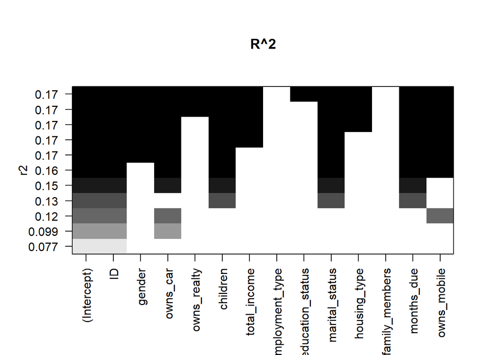

```r
plot(reg_best10, scale = "r2", main = "R^2")
```

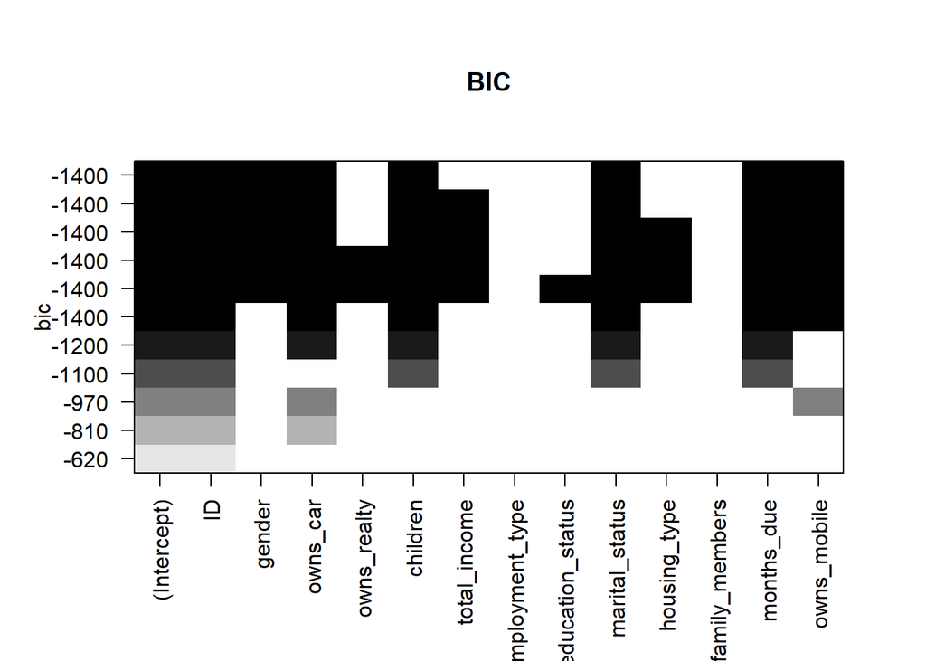

```r
plot(reg_best10, scale = "bic", main = "BIC")
```

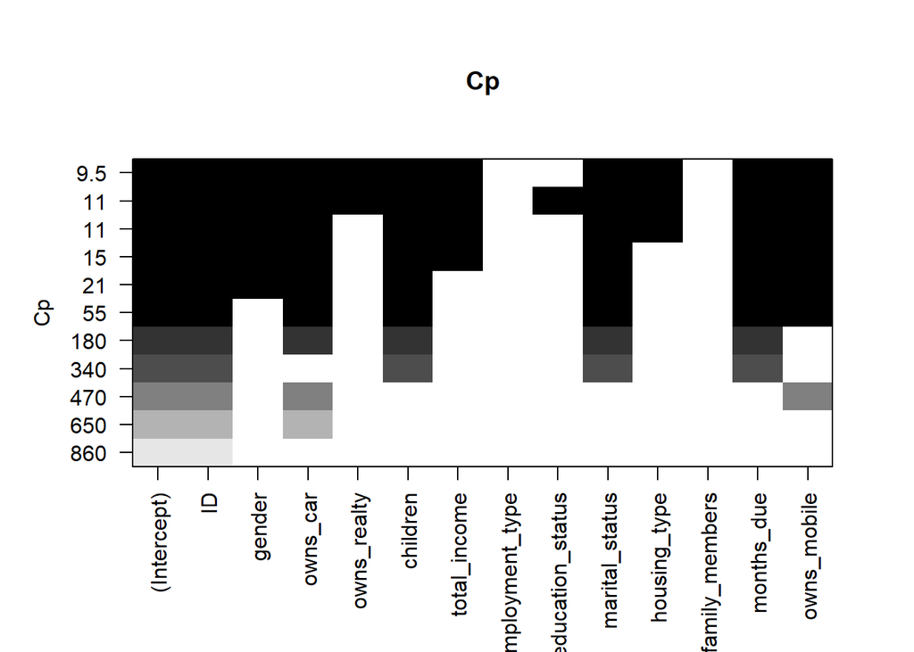

```r
plot(reg_best10, scale = "Cp", main = "Cp")
```

```r
summary(reg_best10)
```

The plots indicate above suggusting that the ideal variables: ‘owns_car’, ‘children’, ‘marital_status’, ‘months_due’, ‘owns_mobile’ and ‘total_income’, which cause the most variance on the target variable.

We will go ahead and create a logistic model explaining how these selected variables have an effect on the target variable(status) and will compare the new model’s accuracy with the earlier model.